# Milestone Report

attila.toth86

2 June 2016

# Introduction

This document aims to present the most recent achievements in the capstone project of Data Science Specialization offered on Coursera by Johns Hopkins University.

The ultimate goal of this project is to create a data application that can predict the next word while typing arbitrary text.

# Goals in the Milestone Report

The goal of this report is to display that working with data have been started and inital analytics have been performed on them. This paper also aims to demonstrate, I am on track with prediction algorithm.

The document is supposed to explain exploratory analyses and goals for eventual app and algorithm.

The motivation for this milestone is to:

1. Demonstrate the major features of the dataset
2. Create a basic summary statistics
3. Report any interesting findings so far
4. Get feedback on plans for creating a prediction algorithm and Shiny app.

# Data Overview

The foundation of the application will be a set of texts provided by the course. They are extracts from

- blogs,
- news,
- and twitter.

The application will use various algorithms and techniques to process these texts and provide the most accurate predictions in reasonable time.

First, let’s take a look at very high level features of the provided dataset. (My application will work on English texts thus I will ignore texts provided in different languages.)

| File Name | File Size (MB) | Number of lines | Number of words | Number of characters |
| --- | --- | --- | --- | --- |
| en_US.blogs.txt | 200.42 | 899288 | 37546246 | 206824505 |
| en_US.news.txt | 196.28 | 1010242 | 34762395 | 203223159 |
| en_US.twitter.txt | 159.36 | 2360148 | 30093369 | 162096031 |

# Exploratory Analyis

This section focuses on the analysis of content of the text. I use techniques of descriptive statistics to reveal the main attributes of documents.

As it is presented in the previous section, the three files contain almost similar amount of information (i.e. file size, number of words and characters) but still my presumption is that the three types of documents have significantly different attributes:

Twitter has been built for short form of communication, limited to 140 characters, that suggest each post (i.e. line in the file) consists of few words, expressing consise opinion in a less formal way

Content of blogs and news might seem similar from technical point of view (i.e. unlimited, continuous paragraphs) but semantically they can differ significantly. News are mainly published by media organizations presenting fact-based statements about our world in proper languange. Blogs, though, can be edited by professional journalists as well (offering quality content like newspaper) but this platform for creating and publishing content is open for anyone thoughout the world. Therefore blogs tend to reflect personal opinion about particular topics being edited by ordinary people that may result in lower quality in content or language.

## Understanding the role of lines

As a starting point I assume that each line represents a single blog post, article or twitter post. I determine the length of each entry by counting characters and words in them. Doing so, the following distributions are revealed:

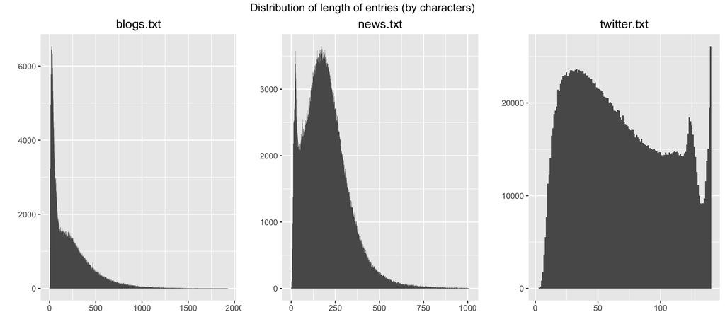

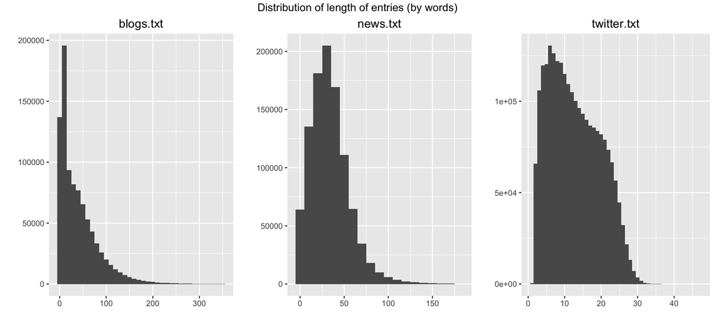

Figures above support my initial presumption that tweets are short messages, their lengths are distributed more or less evenly on the scale of 140 characters. However, the distributions observed at blogs and news do not meet my initial preconception as the graphs show several entries consiting of few words only (i.e. less than 10) that feels incorrect. By looking at these entries, they proved that my presumption was wrong, they are fragmented texts instead of being comprehensive single entries. Thus going forward, it does not make sense to treat these lines as representing regular blog posts or articles.

## Words in text

In this section I focus on the words. In order to analyse them, I need to tokenize (break into words) the documents.

Since the texts I need to work with are relatively big files, for analytic purposes I selected a random 10% sample of the original dataset.

I merged the three separate documents into a single corpus. A corpus is a large and structured set of texts being used to do statistical analysis and hypothesis testing, checking occurrences or validating linguistic rules within a specific language territory. A corpus is designed to be a more or less static container of texts with respect to processing and analysis. This means that the texts in corpus are not designed to be changed internally through (for example) cleaning or pre-processing steps, such as stemming or removing punctuation. Rather, texts can be extracted from the corpus as part of processing, and assigned to new objects, but the idea is that the corpus will remain as an original reference copy so that other analyses – for instance those in which stems and punctuation were required, such as analyzing a reading ease index – can be performed on the same corpus. (via [Wikipedia](https://en.wikipedia.org/wiki/Text_corpus) and [quanteda Quick Start Guide](https://cran.rstudio.com/web/packages/quanteda/vignettes/quickstart.html))

In order to perform statistical analyses on the corpus, features need to be extracted from the texts. The object of document-frequency matrix serves this purpose. In `quanted` the `dfm()` function creates this matrix along with tokenization and data cleaning (i.e. conversion to lower case; stemming words; removing numbers, punctuation, separators, stopwords, special characters, etc.)

For my word prediction application I decided to eliminate

- numbers,
- punctuation,
- separators and
- hashtags.

Also, I converted all words to lower case, kept stopwords and opted stemming out. I believe, removing stopwords would decrease my accuracy, since in the framework of “next word prediction” I can not rule out those ones as they are integrant part of any arbitrary text using for communication. Similarily, stemming words might bring more efficiency in the model but would let space for more inaccuracy by predicting the right word in wrong form.

Given the document-frequency matrix created, the following main attributes can be observed.

Top 50 words by their frequency of appearance:

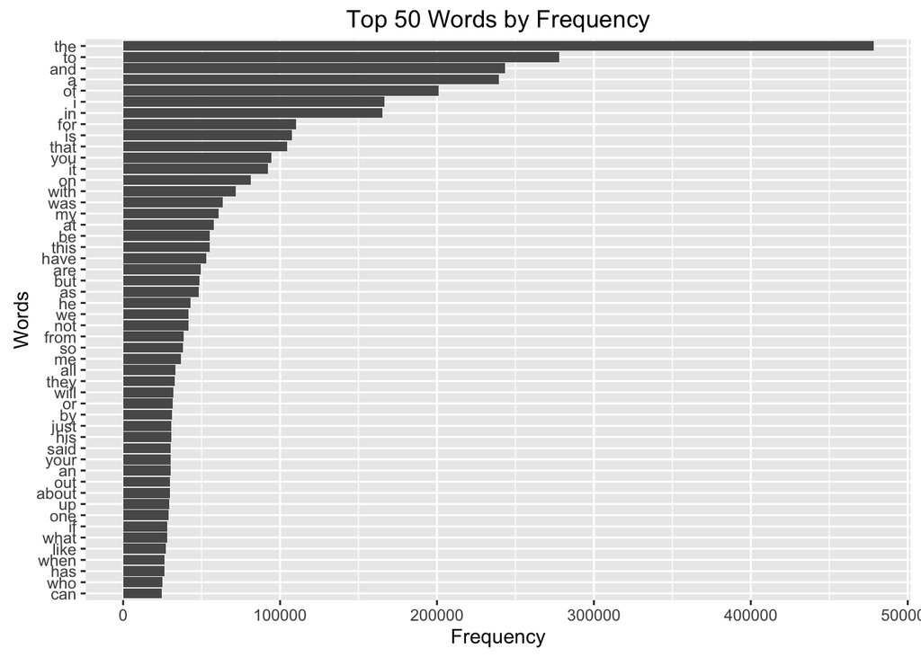

Interestingly, **121172** words out of **215050** occur only once in the sampled text. In order to cover the 50% of all word instances in the text, it is sufficient to use the **141** most frequent words. To cover 90%, this number is **8044**.

## N-Grams

In the previous chapter, I did some analyses in relation with the words of texts. In natural language modeling terminology they are called unigrams. Going forward, I will examine further “grams”, e.g. bigrams & trigrams as potential candidates for the prediction algorythm.

An n-gram is a contiguous sequence of n items from a given sequence of text or speech. An n-gram of size 1 is referred to as a “unigram”; size 2 is a “bigram” (or, less commonly, a “digram”); size 3 is a “trigram”.

An n-gram model is a type of probabilistic language model for predicting the next item in such a sequence in the form of a (n − 1)–order Markov model. Two benefits of n-gram models (and algorithms that use them) are simplicity and scalability – with larger n, a model can store more context with a well-understood space–time tradeoff, enabling small experiments to scale up efficiently.(via [Wikipedia](https://en.wikipedia.org/wiki/N-gram))

Let’s take a look at the most frequent bigrams and trigrams below.

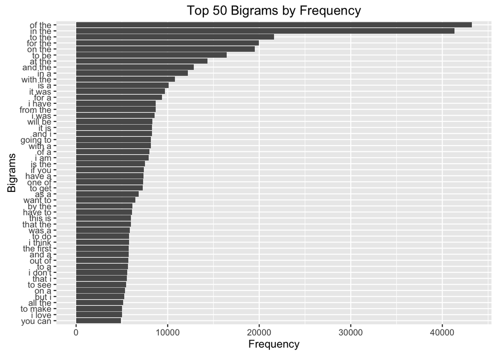

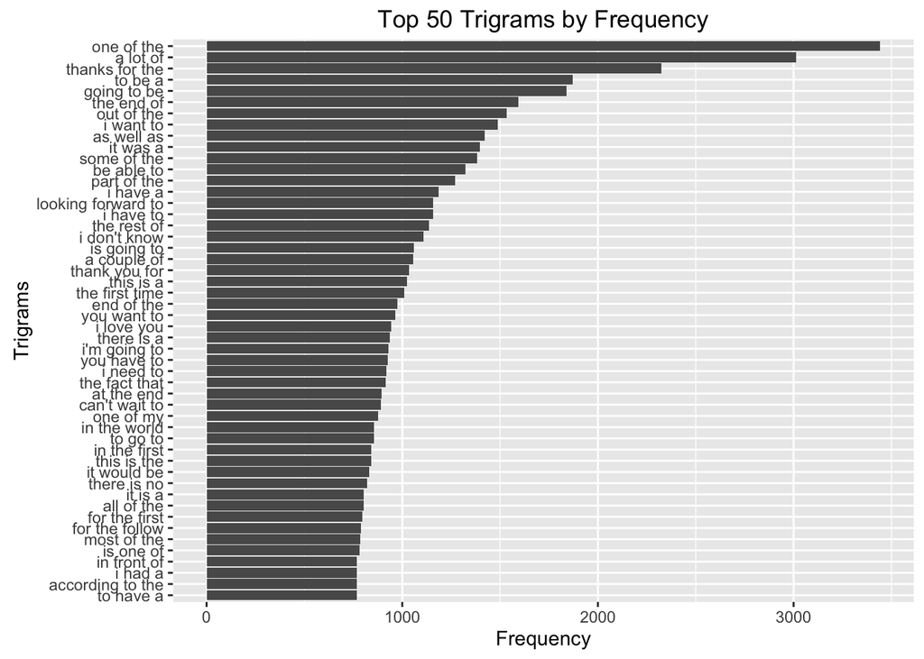

# Future plans

In order to step forward my prediction application, I need to study the words in wider context instead of single words alone. The real prediction question is, by knowing one-two-three already typed word, what, most likely, is the following one? To address this question, I will review certain ngrams in the corpus.